# Image Basics Assessment

## Complete the Tasks in bold below. Keep in mind, you may need to run some of these tasks as Python scripts.

#### TASK: Open the *dog_backpack.jpg* image from the DATA folder and display it in the notebook. Make sure to correct for the RGB order.

```python
import numpy as np
import cv2
import matplotlib.pyplot as plt
import copy
```

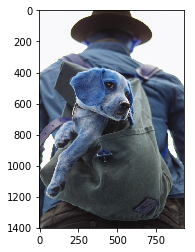

```python
img = cv2.imread('../Data/dog_backpack.jpg')
plt.imshow(img)
```

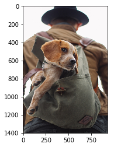

```python
img_RGB = cv2.cvtColor(img,cv2.COLOR_BGR2RGB)
plt.imshow(img_RGB)
```

#### TASK: Flip the image upside down and display it in the notebook.

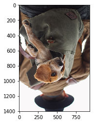

```python
img_flip = cv2.flip(img_RGB,0)
plt.imshow(img_flip)
```

#### TASK: Draw an empty RED rectangle around the dogs face and display the image in the notebook.

```python
### Deep Copying is required to avoid changes in img_RGB
img_Rect = copy.deepcopy(img_RGB)
```

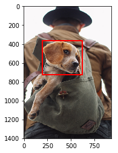

```python
cv2.rectangle(img_Rect,(200,365),(625,725),(255,0,0),10)
plt.imshow(img_Rect)
```

#### TASK: Draw a BLUE TRIANGLE in the middle of the image. The size and angle is up to you, but it should be a triangle (three sides) in any orientation.

```python
img_tri = copy.deepcopy(img_RGB)
```

```python
vertices = np.array([ [200,725] , [625,725] , [415,365] ], dtype=np.int32)
pts = vertices.reshape(-1,1,2)
```

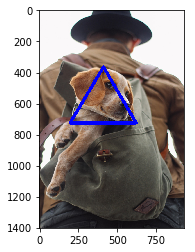

```python
cv2.polylines(img_tri,[pts],isClosed = True,color=(0,0,255),thickness=20)
plt.imshow(img_tri)
```

### BONUS TASK. Can you figure our how to fill in this triangle? It requires a different function that we didn't show in the lecture! See if you can use google search to find it.

[CLICK ME FOR A DIRECT LINK TO THE HINT](https://docs.opencv.org/3.0-beta/modules/imgproc/doc/drawing_functions.html#fillpoly)

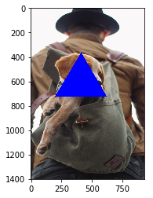

```python
img_fillTri = copy.deepcopy(img_RGB)
cv2.fillPoly(img_fillTri,[pts],(0,0,255))
plt.imshow(img_fillTri)
```

#### TASK: (NOTE: YOU WILL NEED TO RUN THIS AS A SCRIPT). Create a script that opens the picture and allows you to draw empty red circles whever you click the RIGHT MOUSE BUTTON DOWN.